# mrboot

## [Check-In (No R Needed)](https://forms.gle/gaKpikRoyqANKQDr9)

**(Click through the tabs to see the linear models.)**

- Dataset
- M1.
- M1 (b).
- M2.
- M2 (b)

These data come from a study of Haas business students; we’ll focus on the following variables.

- **narc_scale :** a likert scale measure of narcissism - how self-interested the person is (higher scores = the person was higher in narcissism)
- **sex :** the person’s biological sex, measured as a categorical variable with two levels (M = Male; F = Female)
- **test_mean :** the person’s average of two separate testosterone samples.

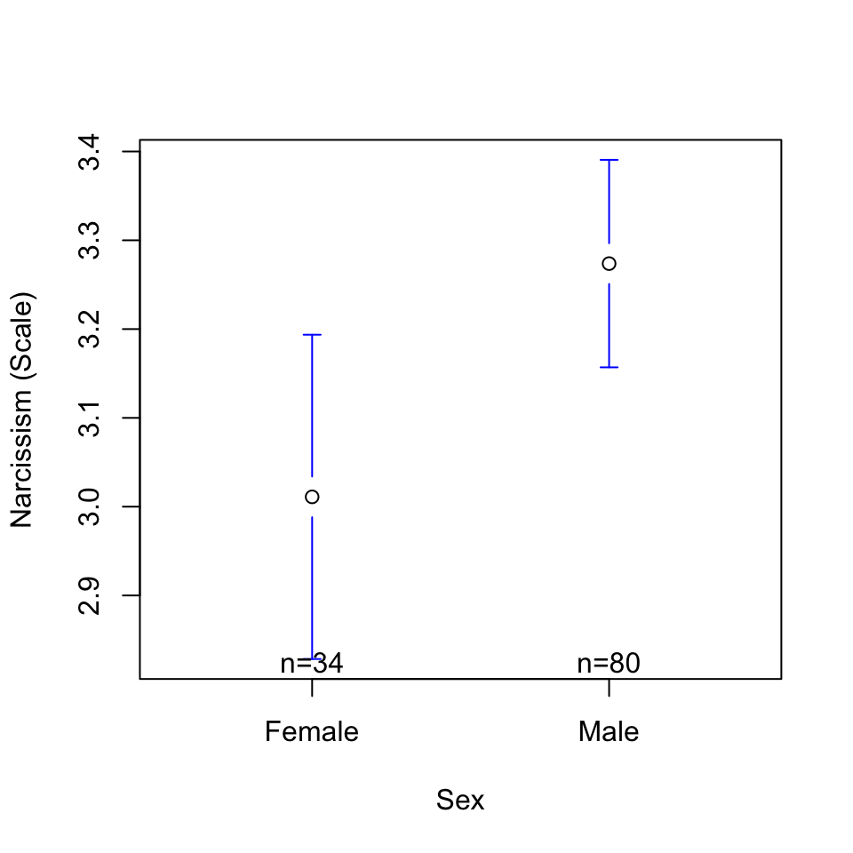

```r
mod1 <- lm(narc_scale ~ sexF, data = d)
plotmeans(narc_scale ~ sexF, data = d, connect = F, xlab = "Sex", ylab = "Narcissism (Scale)")
```

```r
export_summs(mod1, error_pos = "right",
             coefs = c("Intercept" = "(Intercept)",
                       "Sex (Male)" = "sexFMale"), digits = 3)
```

|  | Model 1 |  |
| --- | --- | --- |
| Intercept | 3.011 *** | (0.090) |
| Sex (Male) | 0.263 * | (0.107) |
| N | 114 |  |
| R2 | 0.051 |  |
| *** p < 0.001; ** p < 0.01; * p < 0.05. |  |  |

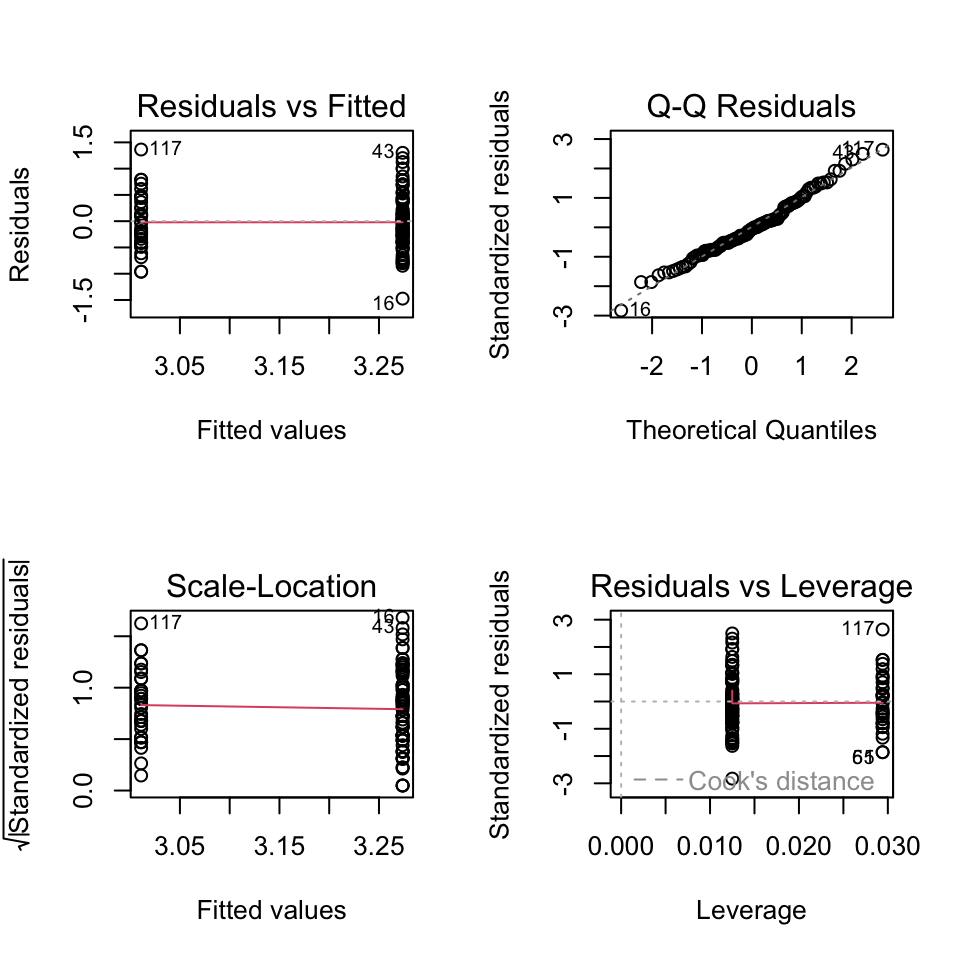

```r
par(mfrow = c(2,2))
plot(mod1)
```

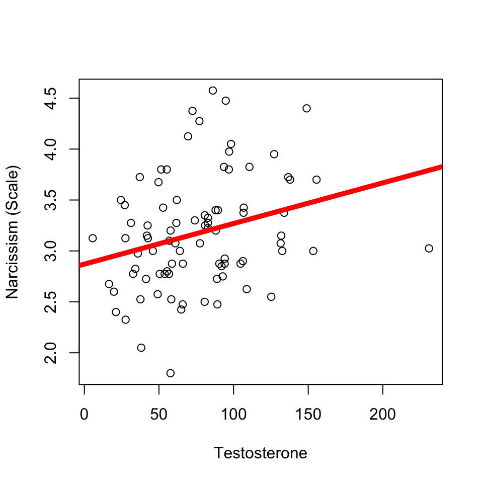

```r
mod2 <- lm(narc_scale ~ test_mean, data = d)
plot(narc_scale ~ test_mean, data = d, xlab = "Testosterone", ylab = "Narcissism (Scale)")
abline(mod2, lwd = 5, col = 'red')
```

```r
export_summs(mod2, error_pos = "right",
             coefs = c("Intercept" = "(Intercept)",
                       "Testosterone" = "test_mean"), digits = 3)
```

|  | Model 1 |  |
| --- | --- | --- |
| Intercept | 2.870 *** | (0.129) |
| Testosterone | 0.004 ** | (0.002) |
| N | 86 |  |
| R2 | 0.077 |  |
| *** p < 0.001; ** p < 0.01; * p < 0.05. |  |  |

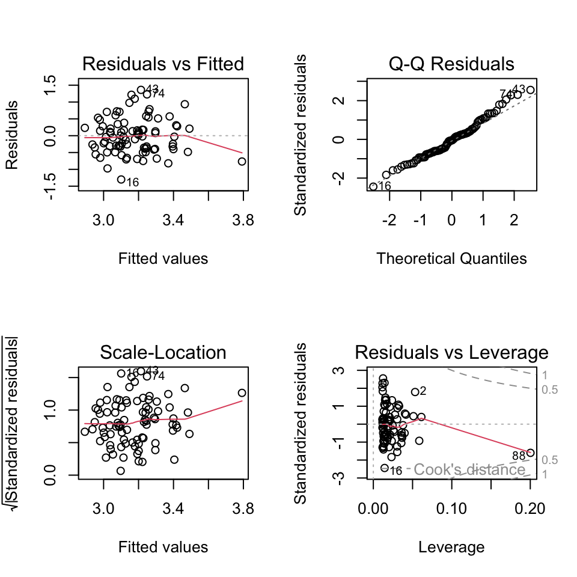

```r
par(mfrow = c(2,2))
plot(mod2)
```

# PART 1 : When Models Get Complicated

### Multiple Regression

- Model 1.
- Model 2.
- IV1 ~ IV2
- Model 3.
- Labeling Changes

Sex is related to narcissism.

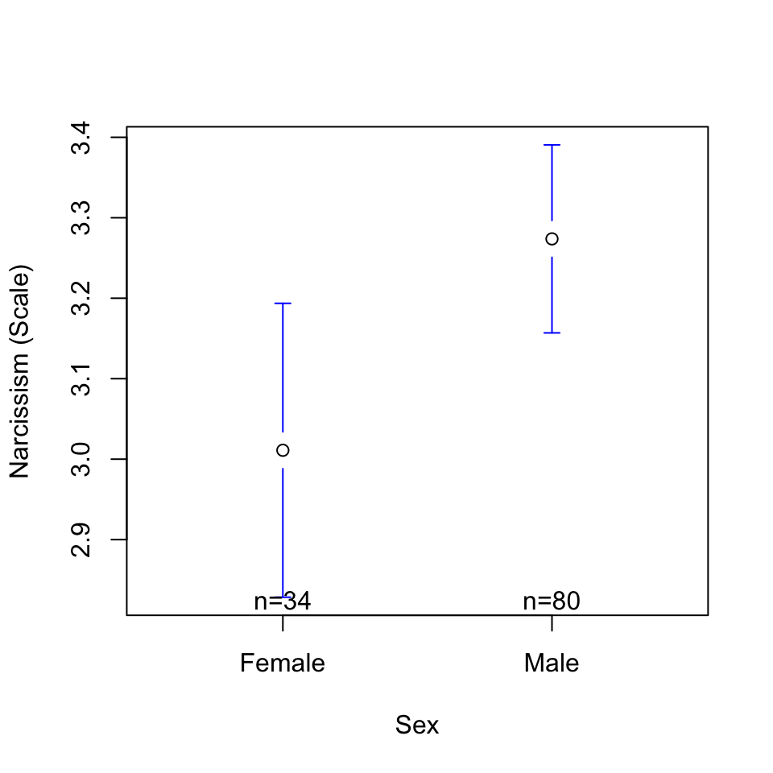

```r
mod1 <- lm(narc_scale ~ sexF, data = d)
plotmeans(narc_scale ~ sexF, data = d, connect = F, xlab = "Sex", ylab = "Narcissism (Scale)")
```

```r
export_summs(mod1, error_format = "", error_pos = "right",
             coefs = c("Intercept" = "(Intercept)",
                       "Sex (Male)" = "sexFMale"), digits = 3)
```

|  | Model 1 |  |
| --- | --- | --- |
| Intercept | 3.011 *** |  |
| Sex (Male) | 0.263 * |  |
| N | 114 |  |
| R2 | 0.051 |  |
| *** p < 0.001; ** p < 0.01; * p < 0.05. |  |  |

Testosterone is related to narcissism…

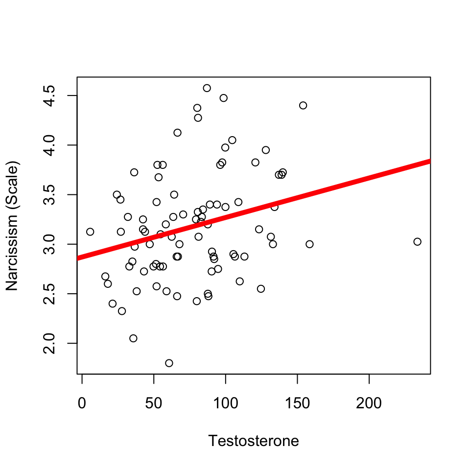

```r
mod2 <- lm(narc_scale ~ test_mean, data = d)
plot(narc_scale ~ test1, data = d, xlab = "Testosterone", ylab = "Narcissism (Scale)")
abline(mod2, lwd = 5, col = 'red')
```

```r
export_summs(mod2, error_format = "", error_pos = "right",
             coefs = c("Intercept" = "(Intercept)",
                       "Testosterone" = "test_mean"), digits = 3)
```

|  | Model 1 |  |
| --- | --- | --- |
| Intercept | 2.870 *** |  |
| Testosterone | 0.004 ** |  |
| N | 86 |  |
| R2 | 0.077 |  |
| *** p < 0.001; ** p < 0.01; * p < 0.05. |  |  |

but if testosterone is related to sex…

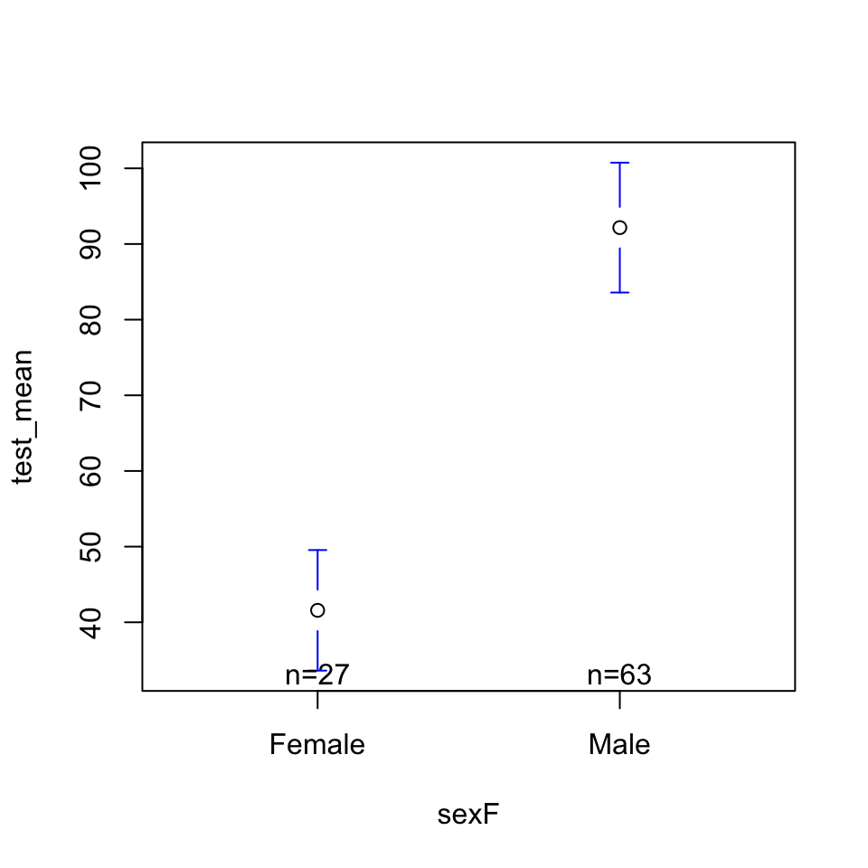

```r
modx <- lm(test_mean ~ sexF, data = d)
plotmeans(test_mean ~ sexF, data = d, connect = F)
```

```r
export_summs(modx, error_format = "", error_pos = "right")
```

|  | Model 1 |  |
| --- | --- | --- |
| (Intercept) | 41.58 *** |  |
| sexFMale | 50.59 *** |  |
| N | 90 |  |
| R2 | 0.37 |  |
| *** p < 0.001; ** p < 0.01; * p < 0.05. |  |  |

**How are they uniquely related?**

```r
mod3 <- lm(narc_scale ~ sexF + test_mean, data = d)
export_summs(mod1, mod2, mod3, error_format = "",  error_pos = "right", digits = 3,
             coefs = c("Testosterone" = "test_mean",
                       "Sex (Male)" = "sexFMale"))
```

|  | Model 1 |  | Model 2 |  | Model 3 |  |
| --- | --- | --- | --- | --- | --- | --- |
| Testosterone |  |  | 0.004 ** |  | 0.004 * |  |
| Sex (Male) | 0.263 * |  |  |  | 0.020 |  |
| N | 114 |  | 86 |  | 86 |  |
| R2 | 0.051 |  | 0.077 |  | 0.077 |  |
| *** p < 0.001; ** p < 0.01; * p < 0.05. |  |  |  |  |  |  |

1. **“Independent” Effect.** The slope of the IV does not change when other variables are added to the model.
2. **“Suppression” Effect.** The slope of the IV gets stronger (in either direction) when other variables are added to the model.
3. “**Mediation” Effect.** The slope of the IV gets closer to zero when other variables are added to the model. *Careful : “mediation” often implies some causal relationship, and it is very hard (/impossible?) to estimate causal relationships without experimental methods. Some links in the weekly readings that go deeper into this.*

## ACTIVITY : Professor (and Student) Practice.

1. Choose a DV from the hormone dataset.
2. Identify two IVs that you think might predict or explain this variable. Which one do you think will be a better predictor of the DV?
3. Do the data cleaning and statistics (linear models) needed to answer this question.
- PREDICT : define the multivariate model. What do you see, and why do this pattern exist?
- ERROR : evaluate the slopes ($r$ or $\beta$) and the change in error ($R^2$) across models.
- CONTROL : how might you use this knowledge?

## Lab 4 Preview :

What is the DV? What is the IV? What are some other variables you might want to include as control variables?

[figure not shown]

## PART 2 : Bootstrap Review

### The Code : a for-loop

1. Questions about the code?
2. What part of this code would you want to adapt to : estimate sampling error of the mean? estimate sampling error in $R^2$
3. What are some other ways you could use a for-loop?

```r
bucket <- array() # defines a space to save my work
for(i in c(1:1000)){ # repeating steps 1000 times & keeping track with i
  newfolk <- sample(1:nrow(d), nrow(d), replace = T) # new index of individuals; same sample size as original data, but wiht replacement
  newdata <- d[newfolk,] # new data, based on the new index
  modX <- lm(DV ~ IV, data = newdata) # new model, based on new data
  extrabucket[i] <- modX[2] # saving the slope (second term of the model)
}
```